# Sensitivity Assignment 3 - 1D systems

Global sensitivity analysis in a 1D groundwater model

EB/LM

11/12/2019

# Learning goals

- Performing global sensitivity analysis on a simple model *(Exercise 1-3)*
- Understanding the importance of the size of the parameter sample for the results of the sensitivity analysis *(Exercise 6,7)*

# Introduction

In this assignment you will apply a global sensitivity analysis to the same 1D groundwater model that we used for the local sensitivity analysis. The model simulates a groundwater extraction well that is located next to a nature reserve (depicted by the reed vegetation), as shown in the figure below, with a river on the left side of the nature reserve.

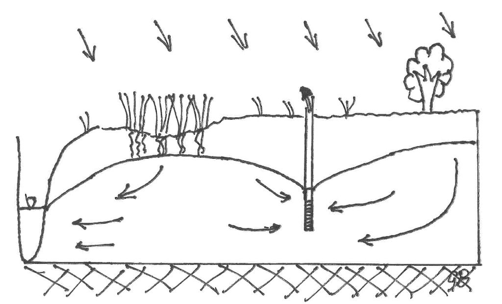

1D saturated stationary groundwater model

```r
rm(list=ls())
library(FVFE1D)
source("samplehelpers.R")
```

First of all, install the following packages from CRAN:  
* `LHS` * `truncnorm`  
* `matrixStats`

# 1. The model

The same model is used as for the Local Sensitivity Analysis 1D assignment. The definition of the model is already provided below:

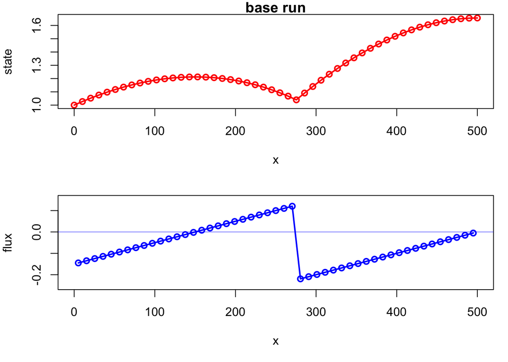

```r
# Domain
domain = c(0,500)

# Internal flux
kDl = 55
kDr = 35
kD.fun = approxfun(domain,c(kDl,kDr)) #gives a (linear) function for the transmissivity
# caution: every time you change kDl or kDr you have to reconstruct this function
internal.flux = function(x,state,gradstate)
  {
  return(-kD.fun(x)*gradstate)
  }

# Define the model
GWmodel = newFLOW1D(domain,internal.flux)
set.name(GWmodel,"base run")

# External fluxes
P = 0.001
add.spatialflux(GWmodel,"P","recharge")
Qwell = -0.35
add.pointflux(GWmodel,at = 275, value= 'Qwell',name = 'well')

# Set boundary conditions
hl = 1
set.BC.fixedstate(GWmodel,"left","hl")

# Numerical setup
nodes = seq(from=domain[1],to=domain[2],length=50)
set.discretisation(GWmodel,nodes,"FV")

# Run the model
control = solve.steps(GWmodel)
plot(GWmodel,fluxplot=TRUE)
```

We focus on the same variable of interest for our sensitivity analysis: groundwater level in the nature reserve.

```r
MRESULT = function()
{
  XS = dataframe.states(GWmodel)
  MH = mean(XS[(XS$x>125)&(XS$x<200),"state"])
  return(MH)
}
```

We store the results of the base run. Formally, a base run is not part of a global sensitivity analysis, but it will be interesting for comparison later on.

```r
M_base = MRESULT()
print(M_base)
```

```
## [1] 1.206285
```

```r
state_base = dataframe.states(GWmodel)$state
```

# 2. Sampling the parameters

The first step in global sensitivity analysis (GSA) is to create a parameter sample. As discussed during the lectures, Latin Hypercube Sampling (LHS) is the most efficient sampling technique. The `GaussianLHS` function provided by `samplehelpers` can be used to create such a sample. The function generates random samples from the given parameter distributions.

This function requires as arguments:

1. the size of the sample
2. a **vector** of parameter means; for this the base values defined above are used
3. a **vector** of standard deviations of the parameters; for this the scales defined above are used
4. a vector of names for the parameters
5. a vector of lower values for the parameters, no values lower than this wil be sampled
6. a vector of upper values for the parameters, no values higher than this will be sampled.

```r
# add your code here:

# parmeans    = c()
# parsd       = c()
# parlower    = c(1, 1, 0, -1, 0.5)
# parupper    = c(1000, 1000, 2, 0, 1.5)
# samplesize  =
# set.seed(237)
# parsample   = GaussianLHS()
```

```r
base  = list(kDl=kDl,kDr=kDr,P=P,Qwell=Qwell,hl=hl)
scale = list(kDl = 1*kDl, kDr = 7.5*kDr, P = 0.25*P,Qwell = -0.4*Qwell, hl = 0.05)

parnames = names(base)
parmeans = unlist(base)
parsd    = unlist(scale)

parlower = c(1, 1, 0, -1, 0.5)
parupper = c(1000, 1000, 2, 0, 1.5)
samplesize = 100
set.seed(237)
parsample = GaussianLHS(samplesize,parmeans,parsd,parnames,parlower,parupper)
```

The following code shows the first lines of the sample, the statistical summary and a plot (don’t forget to remove the EVAL=false argument):

```r
head(parsample)
summary(parsample)
plot(parsample,cex=0.4)
```

More interesting are probably the histograms of the sampled parameter values. Here, we combine the five histograms of the sampled parameters in one plot:

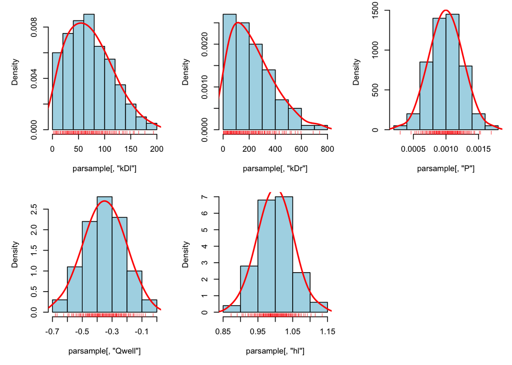

```r
old.par = par(no.readonly=TRUE)
par(mfrow=c(2,3))
par(mar=c(5,5,1,1))
hist(parsample[,"kDl"],main="",col="lightblue",prob=TRUE)
rug(parsample[,"kDl"],col="red")
lines(density(parsample[,"kDl"]),col="red",lwd=2)
hist(parsample[,"kDr"],main="",col="lightblue",prob=TRUE)
rug(parsample[,"kDr"],col="red")
lines(density(parsample[,"kDr"]),col="red",lwd=2)
hist(parsample[,"P"],main="",col="lightblue",prob=TRUE)
rug(parsample[,"P"],col="red")
lines(density(parsample[,"P"]),col="red",lwd=2)
hist(parsample[,"Qwell"],main="",col="lightblue",prob=TRUE)
rug(parsample[,"Qwell"],col="red")
lines(density(parsample[,"Qwell"]),col="red",lwd=2)
hist(parsample[,"hl"],main="",col="lightblue",prob=TRUE)
rug(parsample[,"hl"],col="red")
lines(density(parsample[,"hl"]),col="red",lwd=2)
par(old.par)
```

Evaluate the histograms, are the parameters well sampled?

Write your answer here…

What is the set.seed? Change the seed-number and evaluate the effect on the parameter sample. Also change the sample size and evaluate how this influences the effect of the seed.

Write your answer here…

As all random number generators, the results depend on a so called “seed”. With the same seed the same numbers will be generated; changing the seed generates different random numbers. If the sample size is large enough, changing the seed should not lead to major changes in the parameter distributions. However, in the case of 15 samples (which is too small), a different seed might lead to rather different parameter distributions in the sample, and eventually lead to different sensitivity analysis results.